# ADVANCED DATA ANALYSIS NANODEGREE

### This report is submitted as partial fulfillment of the requirements of the 1st project of the nanodegree

# Project: Investigate The Dataset of Kaggle (TMDb movie data!)

- Introduction
- Data Wrangling
- Exploratory Data Analysis
- Conclusions

## Introduction

This is the TMDb movie data set for data analysis. This data set contains information about 10,000 movies collected from The Movie Database (TMDb), including user ratings and revenue.I would like to find other intresting patterns in the dataset.

This database contains the following features:-

Contain:

Total Rows = 10866  
Total Columns = 21

First thing first, we are going to import the important packages which are:-

- [Numpy](https://numpy.org/) - a library for the Python programming language, adding support for large, multi-dimensional arrays and matrices, along with a large collection of high-level mathematical functions to operate on these arrays.
- [Pandas](https://pandas.pydata.org/) - a library for the Python programming language, it offers data structures and operations for manipulating numerical tables and time series.
- [Matplotlib](https://matplotlib.org/) - Matplotlib is a plotting library for the Python programming language and its numerical mathematics extension NumPy

```python
# importing the packages

import numpy as np
import pandas as pd
import seaborn as sns
import matplotlib.pyplot as plt

sns.set()
```

## Data Wrangling

### General Properties

let's load the dataset and take a peak on its' columns.

```python
# Loading the data
df = pd.read_csv('tmdb-movies.csv')
df.head()
```

|  | id | imdb_id | popularity | budget | revenue | original_title | cast | homepage | director | tagline | ... | overview | runtime | genres | production_companies | release_date | vote_count | vote_average | release_year | budget_adj | revenue_adj |
| --- | --- | --- | --- | --- | --- | --- | --- | --- | --- | --- | --- | --- | --- | --- | --- | --- | --- | --- | --- | --- | --- |
| 0 | 135397 | tt0369610 | 32.985763 | 150000000 | 1513528810 | Jurassic World | Chris Pratt\|Bryce Dallas Howard\|Irrfan Khan\|Vi... | http://www.jurassicworld.com/ | Colin Trevorrow | The park is open. | ... | Twenty-two years after the events of Jurassic ... | 124 | Action\|Adventure\|Science Fiction\|Thriller | Universal Studios\|Amblin Entertainment\|Legenda... | 6/9/15 | 5562 | 6.5 | 2015 | 1.379999e+08 | 1.392446e+09 |
| 1 | 76341 | tt1392190 | 28.419936 | 150000000 | 378436354 | Mad Max: Fury Road | Tom Hardy\|Charlize Theron\|Hugh Keays-Byrne\|Nic... | http://www.madmaxmovie.com/ | George Miller | What a Lovely Day. | ... | An apocalyptic story set in the furthest reach... | 120 | Action\|Adventure\|Science Fiction\|Thriller | Village Roadshow Pictures\|Kennedy Miller Produ... | 5/13/15 | 6185 | 7.1 | 2015 | 1.379999e+08 | 3.481613e+08 |
| 2 | 262500 | tt2908446 | 13.112507 | 110000000 | 295238201 | Insurgent | Shailene Woodley\|Theo James\|Kate Winslet\|Ansel... | http://www.thedivergentseries.movie/#insurgent | Robert Schwentke | One Choice Can Destroy You | ... | Beatrice Prior must confront her inner demons ... | 119 | Adventure\|Science Fiction\|Thriller | Summit Entertainment\|Mandeville Films\|Red Wago... | 3/18/15 | 2480 | 6.3 | 2015 | 1.012000e+08 | 2.716190e+08 |
| 3 | 140607 | tt2488496 | 11.173104 | 200000000 | 2068178225 | Star Wars: The Force Awakens | Harrison Ford\|Mark Hamill\|Carrie Fisher\|Adam D... | http://www.starwars.com/films/star-wars-episod... | J.J. Abrams | Every generation has a story. | ... | Thirty years after defeating the Galactic Empi... | 136 | Action\|Adventure\|Science Fiction\|Fantasy | Lucasfilm\|Truenorth Productions\|Bad Robot | 12/15/15 | 5292 | 7.5 | 2015 | 1.839999e+08 | 1.902723e+09 |
| 4 | 168259 | tt2820852 | 9.335014 | 190000000 | 1506249360 | Furious 7 | Vin Diesel\|Paul Walker\|Jason Statham\|Michelle ... | http://www.furious7.com/ | James Wan | Vengeance Hits Home | ... | Deckard Shaw seeks revenge against Dominic Tor... | 137 | Action\|Crime\|Thriller | Universal Pictures\|Original Film\|Media Rights ... | 4/1/15 | 2947 | 7.3 | 2015 | 1.747999e+08 | 1.385749e+09 |

5 rows × 21 columns

> After Observing the dataset will try in this analysis to keep only relevent data and deleting the unused data. but let's dive more deep to find more observations.

```python
df.info()
```

```
<class 'pandas.core.frame.DataFrame'>
RangeIndex: 10866 entries, 0 to 10865
Data columns (total 21 columns):
id                      10866 non-null int64
imdb_id                 10856 non-null object
popularity              10866 non-null float64
budget                  10866 non-null int64
revenue                 10866 non-null int64
original_title          10866 non-null object
cast                    10790 non-null object
homepage                2936 non-null object
director                10822 non-null object
tagline                 8042 non-null object
keywords                9373 non-null object
overview                10862 non-null object
runtime                 10866 non-null int64
genres                  10843 non-null object
production_companies    9836 non-null object
release_date            10866 non-null object
vote_count              10866 non-null int64
vote_average            10866 non-null float64
release_year            10866 non-null int64
budget_adj              10866 non-null float64
revenue_adj             10866 non-null float64
dtypes: float64(4), int64(6), object(11)
memory usage: 1.7+ MB
```

> **Hmmmmmmmmmmm**, there are alot to take right here. anyway let's list what we have found!

Well, obviously hhere are 10866 columns and 21 columns.

1. “id”, “imdb_id” columns are similar column so we can get rid of one of them. I'd choose “imdb_id” column which is not given any useful information for this analysis. also it's a string and i'd like to deal with integers.

2. “popularity”, “budget”, and “revenue” columns are useful for this analysis and we are going to calculate the profit extract the revenue from the budget column. But previously we need the handle the missing values from budget and revenue column.

3. “original_title”, “cast”, “director” columns have useful information about the movies.

5. “release_date”, and “release_year” columns also important. And we need the convert the release_date column to pandas DateTime object.

## wait! what th??! what is the wrong with those 2 columns "budget_adj", and "revenue_adj" ??

they look wierd and the currency is unknown.But for this dataset i will assume the currency is in US dollor.

[figure not shown]

anyway we are going to drop both of them! XD

> I'm a little curious! does this dataset contains duplicates?

```python
df.duplicated().sum()
```

```
1
```

ops, it does!

Do you know where is that taking us?! (dora mood! xd) yes, data cleaning you are right!

### Data Cleaning

Well, in this phase i'll try to:-

- Drop the duplicated rows.
- Drop the rows which have missing values.
- Change the format of release date into DateTime format.
- Delete the unused columns from Data Frame
- Checking the all columns are in the desired data type.
- Calculating the profit extracting revenue from the budget.

```python
# show duplicates
df[df.duplicated()]
```

|  | id | imdb_id | popularity | budget | revenue | original_title | cast | homepage | director | tagline | ... | overview | runtime | genres | production_companies | release_date | vote_count | vote_average | release_year | budget_adj | revenue_adj |
| --- | --- | --- | --- | --- | --- | --- | --- | --- | --- | --- | --- | --- | --- | --- | --- | --- | --- | --- | --- | --- | --- |
| 2090 | 42194 | tt0411951 | 0.59643 | 30000000 | 967000 | TEKKEN | Jon Foo\|Kelly Overton\|Cary-Hiroyuki Tagawa\|Ian... | NaN | Dwight H. Little | Survival is no game | ... | In the year of 2039, after World Wars destroy ... | 92 | Crime\|Drama\|Action\|Thriller\|Science Fiction | Namco\|Light Song Films | 3/20/10 | 110 | 5.0 | 2010 | 30000000.0 | 967000.0 |

1 rows × 21 columns

```python
# droping that row
df.drop([2090],axis= 0, inplace = True)
```

let's check if that worked!

```python
df.duplicated().sum()
```

```
0
```

```python
df.info()
```

```
<class 'pandas.core.frame.DataFrame'>
Int64Index: 10865 entries, 0 to 10865
Data columns (total 21 columns):
id                      10865 non-null int64
imdb_id                 10855 non-null object
popularity              10865 non-null float64
budget                  10865 non-null int64
revenue                 10865 non-null int64
original_title          10865 non-null object
cast                    10789 non-null object
homepage                2936 non-null object
director                10821 non-null object
tagline                 8041 non-null object
keywords                9372 non-null object
overview                10861 non-null object
runtime                 10865 non-null int64
genres                  10842 non-null object
production_companies    9835 non-null object
release_date            10865 non-null object
vote_count              10865 non-null int64
vote_average            10865 non-null float64
release_year            10865 non-null int64
budget_adj              10865 non-null float64
revenue_adj             10865 non-null float64
dtypes: float64(4), int64(6), object(11)
memory usage: 1.8+ MB
```

hey !!!! did you really checked after me? oh, I'm really disappointed xd!. anyway, let's see about the null values

```python
df.isnull().sum()
```

```
id                         0
imdb_id                   10
popularity                 0
budget                     0
revenue                    0
original_title             0
cast                      76
homepage                7929
director                  44
tagline                 2824
keywords                1493
overview                   4
runtime                    0
genres                    23
production_companies    1030
release_date               0
vote_count                 0
vote_average               0
release_year               0
budget_adj                 0
revenue_adj                0
dtype: int64
```

**oooh, holy moly!**

[figure not shown]

all of that are missing?

Excuse me, I'll first get rid of the unusful features. Then, I'll take care of that!

```python
# droping columns that might not be usful
df.drop(['imdb_id', 'homepage','tagline', 'keywords', 'overview', 'budget_adj','revenue_adj'],axis =1,inplace = True)
df.info()
```

```
<class 'pandas.core.frame.DataFrame'>
Int64Index: 10865 entries, 0 to 10865
Data columns (total 14 columns):
id                      10865 non-null int64
popularity              10865 non-null float64
budget                  10865 non-null int64
revenue                 10865 non-null int64
original_title          10865 non-null object
cast                    10789 non-null object
director                10821 non-null object
runtime                 10865 non-null int64
genres                  10842 non-null object
production_companies    9835 non-null object
release_date            10865 non-null object
vote_count              10865 non-null int64
vote_average            10865 non-null float64
release_year            10865 non-null int64
dtypes: float64(2), int64(6), object(6)
memory usage: 1.2+ MB
```

```python
df.isnull().sum()
```

```
id                         0
popularity                 0
budget                     0
revenue                    0
original_title             0
cast                      76
director                  44
runtime                    0
genres                    23
production_companies    1030
release_date               0
vote_count                 0
vote_average               0
release_year               0
dtype: int64
```

**I think I'll just simply drop those null values.**

```python
df.dropna(how = 'any',inplace = True)
```

let's take a peak on it now!

```python
df.info()
```

```
<class 'pandas.core.frame.DataFrame'>
Int64Index: 9772 entries, 0 to 10865
Data columns (total 14 columns):
id                      9772 non-null int64
popularity              9772 non-null float64
budget                  9772 non-null int64
revenue                 9772 non-null int64
original_title          9772 non-null object
cast                    9772 non-null object
director                9772 non-null object
runtime                 9772 non-null int64
genres                  9772 non-null object
production_companies    9772 non-null object
release_date            9772 non-null object
vote_count              9772 non-null int64
vote_average            9772 non-null float64
release_year            9772 non-null int64
dtypes: float64(2), int64(6), object(6)
memory usage: 1.1+ MB
```

```python
df.isnull().sum()
```

```
id                      0
popularity              0
budget                  0
revenue                 0
original_title          0
cast                    0
director                0
runtime                 0
genres                  0
production_companies    0
release_date            0
vote_count              0
vote_average            0
release_year            0
dtype: int64
```

## I will change the 'release data' column from object which is string to datatime.

```python
# changing columns to the right data type
df['release_date'] = pd.to_datetime(df['release_date'])
df['release_date'].head()
```

```
0   2015-06-09
1   2015-05-13
2   2015-03-18
3   2015-12-15
4   2015-04-01
Name: release_date, dtype: datetime64[ns]
```

### Checking if our dataset contains runtime of zero or less than zero

```python
# making a mask of zero values
is_runtime_zero = df['runtime'] == 0
df[is_runtime_zero].shape , df[is_runtime_zero].index.values
```

```
((13, 14),
 array([  92,  334,  445,  486, 1289, 1293, 3329, 3857, 4944, 5695, 5920,
        5938, 6934]))
```

### that is alot, let's take a peak on them!

```python
df[is_runtime_zero]
```

|  | id | popularity | budget | revenue | original_title | cast | director | runtime | genres | production_companies | release_date | vote_count | vote_average | release_year |
| --- | --- | --- | --- | --- | --- | --- | --- | --- | --- | --- | --- | --- | --- | --- |
| 92 | 370687 | 1.876037 | 0 | 0 | Mythica: The Necromancer | Melanie Stone\|Adam Johnson\|Kevin Sorbo\|Nicola ... | A. Todd Smith | 0 | Fantasy\|Action\|Adventure | Arrowstorm Entertainment\|Camera 40 Productions... | 2015-12-19 | 11 | 5.4 | 2015 |
| 334 | 361931 | 0.357654 | 0 | 0 | Ronaldo | Cristiano Ronaldo | Anthony Wonke | 0 | Documentary | On The Corner Films\|We Came, We Saw, We Conque... | 2015-11-09 | 80 | 6.5 | 2015 |
| 445 | 353345 | 0.218528 | 0 | 0 | The Exorcism of Molly Hartley | Sarah Lind\|Devon Sawa\|Gina Holden\|Peter MacNei... | Steven R. Monroe | 0 | Horror | WT Canada Productions | 2015-10-09 | 52 | 5.0 | 2015 |
| 486 | 333653 | 0.176744 | 0 | 0 | If There Be Thorns | Heather Graham\|Jason Lewis\|Rachael Carpani\|Mas... | Nancy Savoca | 0 | TV Movie\|Drama | A+E Studios\|Jane Startz Productions | 2015-04-05 | 11 | 5.4 | 2015 |
| 1289 | 286372 | 0.037459 | 3250000 | 0 | Treehouse | J. Michael Trautmann\|Dana Melanie\|Daniel Fredr... | Michael G. Bartlett | 0 | Thriller\|Horror\|Mystery | Tiberius Film | 2014-10-20 | 16 | 3.4 | 2014 |
| 1293 | 286256 | 0.036904 | 0 | 0 | Tim Maia | Robson Nunes\|Babú Santana\|Alinne Moraes\|Cauã... | Mauro Lima | 0 | Documentary\|Drama\|Music | Globo Filmes | 2014-10-30 | 14 | 6.0 | 2014 |
| 3329 | 20414 | 0.082898 | 0 | 0 | Grande, grosso e Verdone | Carlo Verdone\|Claudia Gerini\|Eva Riccobono\|Vit... | Carlo Verdone | 0 | Family | Filmauro | 2008-03-07 | 35 | 5.3 | 2008 |
| 3857 | 289097 | 0.095583 | 0 | 0 | Cell 213 | Bruce Greenwood\|Eric Balfour\|Michael Rooker\|De... | Stephen Kay | 0 | Horror | Access Motion Pictures | 2011-06-10 | 13 | 5.2 | 2011 |
| 4944 | 158150 | 0.026459 | 0 | 0 | How to Fall in Love | Brooke D'Orsay\|Eric Mabius\|Jody Thompson\|Gina ... | Mark Griffiths | 0 | Comedy\|Romance\|TV Movie | Annuit Coeptis Entertainment Inc.\|Annuit Coept... | 2012-07-21 | 11 | 4.7 | 2012 |
| 5695 | 224815 | 0.417739 | 0 | 0 | Skinwalker Ranch | Steve Berg\|Kyle Davis\|Erin Cahill\|Jon Gries\|De... | Devin McGinn | 0 | Thriller\|Horror\|Science Fiction | DeepStudios | 2013-10-30 | 27 | 4.3 | 2013 |
| 5920 | 248842 | 0.165765 | 0 | 0 | The Food Guide to Love | Richard Coyle\|Leonor Watling\|Ginés García Mi... | Dominic Harari\|Teresa Pelegri | 0 | Romance\|Comedy | Haut et Court\|Parallel Film Productions\|Fox In... | 2013-12-18 | 12 | 5.6 | 2013 |
| 5938 | 191562 | 0.147188 | 0 | 0 | Go Goa Gone | Saif Ali Khan\|Anand Tiwari\|Vir Das\|Pooja Gupta | Krishna D.K.\|Raj Nidimoru | 0 | Comedy\|Horror | Eros International | 2013-05-10 | 16 | 5.3 | 2013 |
| 6934 | 13713 | 0.071872 | 0 | 0 | Jean-Philippe | Fabrice Luchini\|Johnny Hallyday\|Jackie Berroye... | Laurent Tuel | 0 | Comedy | Fidélité Productions\|StudioCanal\|TF1 Films P... | 2006-04-05 | 26 | 5.6 | 2006 |

### so I noticed that those rows not only has runtime zero values which it might be a typo errors but also the budget and the revenue colomns has zero values !

**I'll drop those also!**

```python
df.drop(labels = [92,  334,  445,  486, 1289, 1293, 3329, 3857, 4944, 5695, 5920,
        5938, 6934], inplace = True)
```

let's check again

```python
df[is_runtime_zero]
```

|  | id | popularity | budget | revenue | original_title | cast | director | runtime | genres | production_companies | release_date | vote_count | vote_average | release_year |
| --- | --- | --- | --- | --- | --- | --- | --- | --- | --- | --- | --- | --- | --- | --- |

```python
df.info()
```

```
<class 'pandas.core.frame.DataFrame'>
Int64Index: 9759 entries, 0 to 10865
Data columns (total 14 columns):
id                      9759 non-null int64
popularity              9759 non-null float64
budget                  9759 non-null int64
revenue                 9759 non-null int64
original_title          9759 non-null object
cast                    9759 non-null object
director                9759 non-null object
runtime                 9759 non-null int64
genres                  9759 non-null object
production_companies    9759 non-null object
release_date            9759 non-null datetime64[ns]
vote_count              9759 non-null int64
vote_average            9759 non-null float64
release_year            9759 non-null int64
dtypes: datetime64[ns](1), float64(2), int64(6), object(5)
memory usage: 1.1+ MB
```

```python
df.shape
```

```
(9759, 14)
```

## Exploratory Data Analysis

> now officaly we can get to the point!

### Question 1 (is there any relation between the Revenue, Popularity, and Rating?!)

I'll do a function that will help visualizing the distribution of Revenue, Popularity, and Rating using the matplotlib plotbox!

```python
def plot_box(feature):
    df.boxplot(feature, vert=False,showfliers=False)
```

now since the function is ready let's use it !

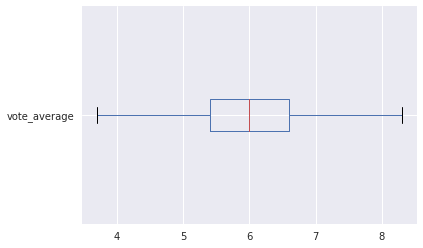

```python
# Visualizing the distribution of Ratings.
plot_box('vote_average')
```

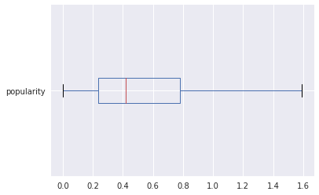

```python
# distribution of Popularity.
plot_box('popularity')
```

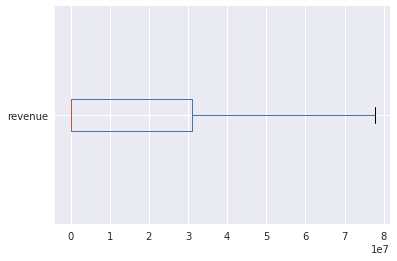

```python
# distribution of Revenue.
plot_box('revenue')
```

**now let's see the relationship or the correlation between Revenue vs Popularity using the matblotlib scatter-plot**

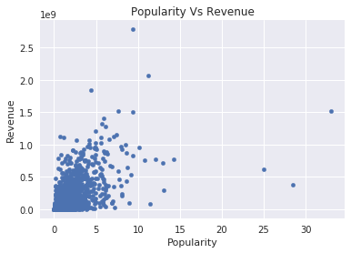

```python
# Scatter plot of Revenue vs Popularity
df.plot(x='popularity',y='revenue',kind='scatter')
plt.title('Popularity Vs Revenue')
plt.xlabel('Popularity')
plt.ylabel('Revenue');
```

here we can find that Revenue increases with increase in Popularity.

**now let's see the relationship or the correlation between Popularity vs Ratings using the matblotlib scatter-plot**

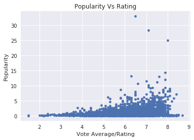

```python
# Scatter plot of Popularity vs Ratings
df.plot(x='vote_average',y='popularity',kind='scatter')
plt.title('Popularity Vs Rating')
plt.xlabel('Vote Average/Rating')
plt.ylabel('Popularity');
```

**now let's see the relationship or the correlation between Revenue vs Ratings using the matblotlib scatter-plot**

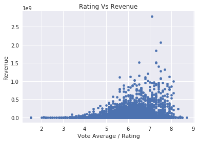

```python
# Scatter plot of Revenue vs Ratings
df.plot(x='vote_average',y='revenue',kind='scatter')
plt.title('Rating Vs Revenue')
plt.xlabel('Vote Average / Rating')
plt.ylabel('Revenue');
```

it's obvious that the relationship between the ratings vs revenue, and Popularity vs Ratings are **rightly-biased**

### Question 2 (Which Movie Has The Highest profit?!)

well, I think to do this we would need first to calculate Profit for each of the movie. let's do it!

```python
df['profit'] = df['revenue']-df['budget']
df['profit'] = df['profit'].apply(np.int64)
df['budget'] = df['budget'].apply(np.int64)
df['revenue'] = df['revenue'].apply(np.int64)
```

let's find out what are the top ten profitable movies?

```python
def top_10(col_name,size=10):
    #find the all times top 10 for a fiven column
    #sort the given column and select the top 10
    df_sorted = pd.DataFrame(df[col_name].sort_values(ascending=False))[:size]
    df_sorted['original_title'] = df['original_title']
    plt.figure(figsize=(12,6))
    #Calculate the avarage
    avg = np.mean(df[col_name])
    sns.barplot(x=col_name, y='original_title', data=df_sorted, label=col_name)
    plt.axvline(avg, color='k', linestyle='--', label='mean')
    if (col_name == 'profit' or col_name == 'budget' or col_name == 'revenue'):
        plt.xlabel(col_name.capitalize() + ' (U.S Dolar)')
    else:
        plt.xlabel(col_name.capitalize())
    plt.ylabel('')
    plt.title('Top 10 Movies in: ' + col_name.capitalize())
    plt.legend()
```

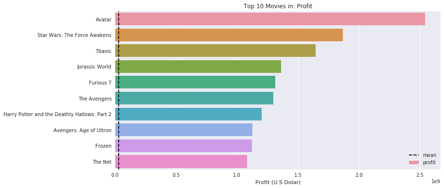

```python
top_10('profit')
```

As we can see that 'Avatar' movie Directed by James Cameron earn the highest profit in all, making over 2.5B in profit in this dataset.

### Research Question 3 (Which genres was more used during the timelife of this dataset)

```python
print(df['release_date'].min())
```

```
1970-01-03 00:00:00
```

okay so form 1970 till now

We are going to write another function to answer the following question. This function could take the column like genres,then count the values of these column to find out more filmed genres in this time of period.

```python
from matplotlib import gridspec
def split_count_data(col_name, size=15):
    ##function which will take any column as argument from which data is need to be extracted and keep track of count
    #take a given column, and separate the string by '|'
    data = df[col_name].str.cat(sep='|')
    #storing the values separately in the series
    data = pd.Series(data.split('|'))
    #Let's count the most frequenties values for given column
    count = data.value_counts(ascending=False)
    count_size = count.head(size)
    #Setting axis name for multiple names
    if (col_name == 'production_companies'):
        sp = col_name.split('_')
        axis_name = sp[0].capitalize()+' '+ sp[1].capitalize()
    else:
        axis_name = col_name.capitalize()
    fig = plt.figure(figsize=(14, 6))
    #set the subplot
    gs = gridspec.GridSpec(1,2, width_ratios=[2,2])
    #count of given column on the bar plot
    ax0 = plt.subplot(gs[0])
    count_size.plot.barh()
    plt.xlabel('Number of Movies')
    plt.ylabel(axis_name)
    plt.title('The Most '+str(size)+' Filmed ' +axis_name+' Versus Number of Movies')
    ax = plt.subplot(gs[1])
    #setting the explode to adjust the pei chart explode variable to any given size
    explode = []
    total = 0
    for i in range(size):
         total = total + 0.015
         explode.append(total)
    #pie chart for given size and given column
    ax = count_size.plot.pie(autopct='%1.2f%%', shadow=True, startangle=0, pctdistance=0.9, explode=explode)
    plt.title('The most '+str(size)+' Filmed ' +axis_name+ ' in Pie Chart')
    plt.xlabel('')
    plt.ylabel('')
    plt.axis('equal')
    plt.legend(loc=9, bbox_to_anchor=(1.4, 1))
```

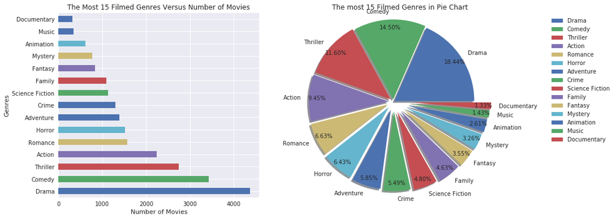

```python
split_count_data("genres")
```

### Research Question 4 (Which Director has produced the best movies in 2015?)

```python
df.loc[df['release_year'].idxmax()]
```

```
id                                                                 135397
popularity                                                        32.9858
budget                                                          150000000
revenue                                                        1513528810
original_title                                             Jurassic World
cast                    Chris Pratt|Bryce Dallas Howard|Irrfan Khan|Vi...
director                                                  Colin Trevorrow
runtime                                                               124
genres                          Action|Adventure|Science Fiction|Thriller
production_companies    Universal Studios|Amblin Entertainment|Legenda...
release_date                                          2015-06-09 00:00:00
vote_count                                                           5562
vote_average                                                          6.5
release_year                                                         2015
profit                                                         1363528810
Name: 0, dtype: object
```

I like that movie, that reminded me with sth

[figure not shown]

**I'm sorry, couldn't help it! xd**

### back to our question (Which Director has produced the best movies in 2015?) to do that i'll first find the top 5 Directors for 2015 based on Movie Ratings.

```python
# Filtering the dataset to movies released in 2015 alone
df_dir=df[df['release_year'] == 2015]
```

now let's **grouped** our df_dir dataframe **by** Director Names along with the mean of different movies released by them in 2015

```python
director_data = df_dir.groupby('director').mean().vote_average
```

let's take a peak on that dataframe

```python
director_data
```

```
director
Aaron Hann|Mario Miscione         6.1
Aaron Keeling|Austin Keeling      3.8
Aaron Moorhead|Justin Benson      6.5
Adam Brooks|Matthew Kennedy       6.0
Adam Egypt Mortimer               3.9
Adam Green                        5.4
Adam MacDonald                    5.8
Adam Mason                        3.9
Adam Massey                       4.9
Adam McKay                        7.3
Adam Salky                        5.7
Adam Schindler                    5.8
Afonso Poyart                     6.2
Aisling Walsh                     7.8
Alan Taylor                       5.8
Alberto Marini                    5.3
Alec Gillis                       4.2
Alejandro AmenÃ¡bar               5.2
Alejandro GonzÃ¡lez IÃ±Ã¡rritu    7.2
Alejandro Monteverde              7.1
Aleksander Bach                   5.5
Alex Garcia Lopez                 4.5
Alex Garland                      7.6
Alex Gibney                       7.0
Alex Kalymnios                    6.3
Alex Kendrick                     6.9
Alex Pillai                       5.3
Alex Ross Perry                   5.6
Alex Winter                       6.1
Alfonso Gomez-Rejon               7.7
                                 ...
Tim Russ                          4.1
Toby Genkel|Sean McCormack        5.7
Todd Haynes                       7.1
Todd Strauss-Schulson             6.6
Tom Daley                         5.3
Tom Gianas|Ross Shuman            4.3
Tom Hooper                        7.3
Tom McCarthy                      7.8
```

[output cut: 8 more lines]

```
Wayne Blair                       5.9
Werner Herzog                     6.0
Wes Ball                          6.4
Will Canon                        5.0
Will Slocombe                     5.9
William Kaufman                   5.7
William Monahan                   4.3
Wim Wenders                       5.1
Woody Allen                       6.1
Yorgos Lanthimos                  6.6
Zach Lipovsky                     4.9
Zachary Sluser                    5.0
Zackary Adler                     4.7
Zeke Norton                       5.5
Name: vote_average, Length: 541, dtype: float64
```

**Well, it worked just fine but I guess I'll need to sort them based on the ratings**

```python
sort_dir = director_data.sort_values(ascending=False)
```

```python
sort_dir.head()
```

```
director
Andrew Jarecki      8.4
Don Hertzfeldt      8.2
Mark Neale          8.0
Pete Docter         8.0
Lenny Abrahamson    8.0
Name: vote_average, dtype: float64
```

**now let's visualize that--> directors to their average ratings of movies released in 2015**

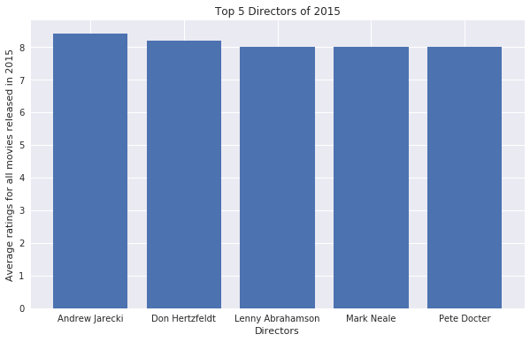

```python
plt.subplots(figsize=(10,6))
plt.bar(sort_dir.index[:5],sort_dir[:5])
plt.title('Top 5 Directors of 2015')
plt.xlabel('Directors')
plt.ylabel('Average ratings for all movies released in 2015');
```

## Conclusions

[figure not shown]

> Limitations : Here I faced various limitations. Firstly there were many rows within the dataframe which contained a certain amount of null values(a lot to be honest). So, first I had to DORP those rows. Furthermore, the data also contained a duplicated value row (2090), which had to be removed, following a re-check of null values for our key parameters.

**Question 2**: As we can see that 'Avatar' movie Directed by James Cameron earn the highest profit in all, making over 2.5B in profit in this dataset. and 'Star Wars' and 'Titanic' are the most profitable movies.

> Limitations : Here I faced various limitations. There were no info about the profit of each movie but there was about the revenue and the budget of each movie so I calculated it

  > Limitations : Here I faced various limitations. The data in the columns of (Directors, genres, production_companies) are sperated by '|', so I needed a function which will take any column as argument from which data is need to be extracted and keep track of count takeing a given column, and separate the string by '|' .

**Question 4** I'm clearly able to list out the top 5 Directors of 2015 based on the mean calculated for the average ratings of various movies released by them in 2015. so, we can conclude that, **'Andrew Jarecki'** with mean average rating of '8.4', wins, then comes

- 'Don Hertzfeldt' with mean average rating of '8.2'.
- 'Mark Neale' with mean average rating of '8.0'.
- 'Pete Docter' with mean average rating of '8.0'.
- 'Lenny Abrahamson'with mean average rating of '8.0'.

  > Limitations : Here I faced various limitations. Firstly there were many rows within the filtered dataframe containing data corresponding to movies released in 2015, having null values. So, first we had to drop those entries. also I didn't need many irrelevant fields present in the data but directors names and the ratings of their movies. So, I discarded the others fields.

```python
from subprocess import call
call(['python', '-m', 'nbconvert', 'Investigate_a_Dataset.ipynb'])
```

```
0
```